# Conjugate Families

July 10, 2025  
Thursday

## Introduction: Normal-Normal Model

- So far, we have learned two conjugate families:
  - Beta-Binomial (binary outcomes)
    - $y \sim \text{Bin}(n, \pi)$ (data distribution)
    - $\pi \sim \text{Beta}(\alpha, \beta)$ (prior distribution)
    - $\pi|y \sim \text{Beta}(\alpha+y, \beta+n-y)$ (posterior distribution)
  - Gamma-Poisson (count outcomes)
    - $Y_i | \lambda \overset{ind}\sim \text{Pois}(\lambda)$ (data distribution)
    - $\lambda \sim \text{Gamma}(s, r)$ (prior distribution)
    - $\lambda | \overset{\to}y \sim \text{Gamma}\left( s + \sum y_i, r + n \right)$ (posterior distribution)
- Now, we will learn about another conjugate family, the Normal-Normal, for continuous outcomes.

## Example Set Up

- As scientists learn more about brain health, the dangers of concussions are gaining greater attention.
- We are interested in $\mu$, the average volume (cm<sup>3</sup>) of a specific part of the brain: the hippocampus.
- [Wikipedia](https://en.wikipedia.org/wiki/Hippocampus#Other_mammals) tells us that among the general population of human adults, each half of the hippocampus has volume between 3.0 and 3.5 cm<sup>3</sup>.
  - Total hippocampal volume of both sides of the brain is between 6 and 7 cm<sup>3</sup>.
  - Let’s assume that the mean hippocampal volume among people with a history of concussions is also somewhere between 6 and 7 cm<sup>3</sup>.
- We will take a sample of $n=25$ participants and update our belief.

## The Normal Model

- Let $Y \in \mathbb{R}$ be a continuous random variable.
  - The variability in $Y$ may be represented with a Normal model with mean parameter $\mu \in \mathbb{R}$ and standard deviation parameter $\sigma > 0$.
- The Normal model’s pdf is as follows,

$$f(y) = \frac{1}{\sqrt{2\pi\sigma^2}} \exp \left\{ \frac{-(y-\mu)^2}{2\sigma^2} \right\}$$

## The Normal Model

- If we vary $\mu$,

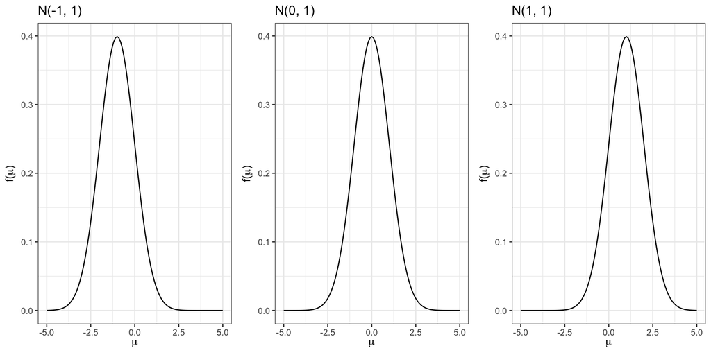

## The Normal Model

- If we vary $\sigma$,

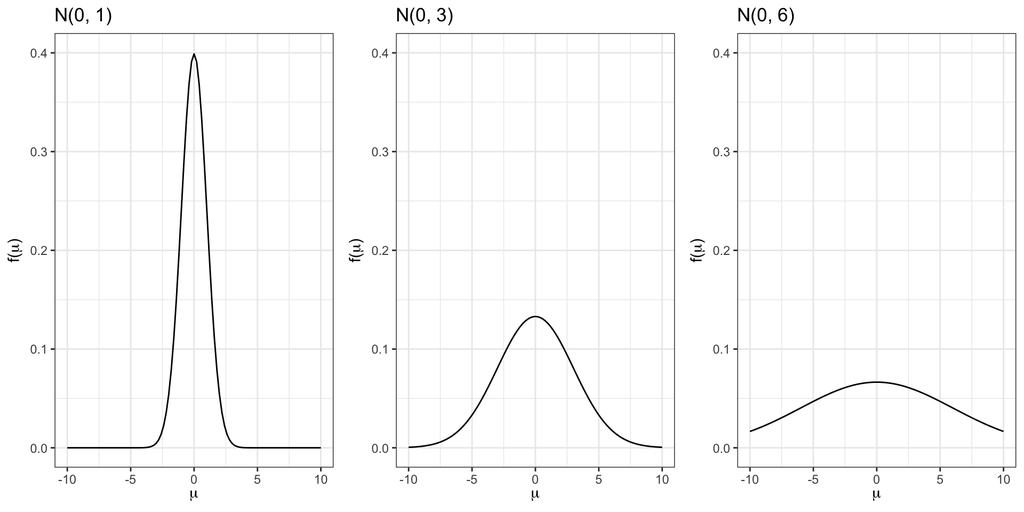

## The Normal Model

- Our data model is as follows,

$$Y_i | \mu \sim N(\mu, \sigma^2)$$

- The joint pdf is as follows,

$$f(\overset{\to}y | \mu) = \prod_{i=1}^n f(y_i | \mu) = \prod_{i=1}^n \frac{1}{\sqrt{2 \pi \sigma^2}} \exp \left\{ \frac{-(y_i-\mu)^2}{2\sigma^2} \right\}$$

- Meaning the likelihood is as follows,

$$L(\mu|\overset{\to}y) \propto \prod_{i=1}^n \frac{1}{\sqrt{2 \pi \sigma^2}} \exp \left\{ \frac{-(y_i-\mu)^2}{2\sigma^2} \right\} = \exp \left\{ \frac{- \sum_{i=1}^n(y_i-\mu)^2}{2\sigma^2} \right\}$$

## The Normal Model

- Our data model is as follows,

$$Y_i | \mu \sim N(\mu, \sigma^2)$$

- Returning to our brain analysis, we will assume that the hippocampal volumes of our $n = 25$ subjects have a normal distribution with mean $\mu$ and standard deviation $\sigma$.
  - Right now, we are only interested in $\mu$, so we assume $\sigma = 0.5$ cm<sup>3</sup>
  - This choice suggests that most people have hippocampal volumes within $2 \sigma = 1$ cm<sup>3</sup>.

## Normal Prior

- We know that with $Y_i | \mu \sim N(\mu, \sigma^2)$, $\mu \in \mathbb{R}$.
  - We think a normal prior for $\mu$ is reasonable.
- Thus, we assume that $\mu$ has a normal distribution around some mean, $\theta$, with standard deviation, $\tau$.

$$\mu \sim N(\theta, \tau^2),$$

- meaning that $\mu$ has prior pdf

$$f(\mu) = \frac{1}{\sqrt{2 \pi \tau^2}} \exp \left\{ \frac{-(\mu - \theta)^2}{2 \tau^2} \right\}$$

## Tuning the Normal Prior

- We can tune the hyperparameters $\theta$ and $\tau$ to reflect our understanding and uncertainty about the average hippocampal volume ($\mu$) among people with a history of concussions.
- Wikipedia showed us that hippocampal volumes tend to be between 6 and 7 cm<sup>3</sup> $\to$ $\theta=6.5$.
- When we set the standard deviation we can check the plausible range of values of $\mu$:
  - Follow up: why 2?

$$\theta \pm 2 \times \tau$$

- If we assume $\tau=0.4$,

$$(6.5 \pm 2 \times 0.4) = (5.7, 7.3)$$

## Tuning the Normal Prior

- Thus, our tuned prior is $\mu \sim N(6.5, 0.4^2)$

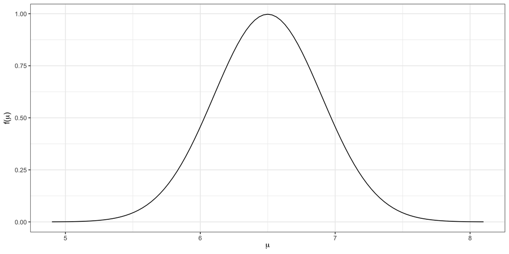

- This range incorporates our uncertainty - it is wider than the Wikipedia range.

## Normal-Normal Conjugacy

- Let $\mu \in \mathbb{R}$ be an unknown mean parameter and $(Y_1, Y_2, ..., Y_n)$ be an independent $N(\mu, \sigma^2)$ sample where $\sigma$ is assumed to be known.
- The Normal-Normal Bayesian model is as follows:

$$\begin{align*}
Y_i | \mu &\overset{\text{iid}} \sim N(\mu, \sigma^2) \\
\mu &\sim N(\theta, \tau^2) \\
\mu | \overset{\to}y &\sim N\left( \theta \frac{\sigma^2}{n\tau^2 + \sigma^2} + \bar{y} \frac{n\tau^2}{n\tau^2 + \sigma^2}, \frac{\tau^2 \sigma^2}{n \tau^2 + \sigma^2} \right)
\end{align*}$$

## Normal-Normal Conjugacy

- Let’s think about our posterior and some implications,

$$\mu | \overset{\to}y \sim N\left( \theta \frac{\sigma^2}{n\tau^2 + \sigma^2} + \bar{y} \frac{n\tau^2}{n\tau^2 + \sigma^2}, \frac{\tau^2 \sigma^2}{n \tau^2 + \sigma^2} \right)$$

- What happens as $n$ increases?

## Normal-Normal Conjugacy

- Let’s think about our posterior and some implications,

$$\mu | \overset{\to}y \sim N\left( \theta \frac{\sigma^2}{n\tau^2 + \sigma^2} + \bar{y} \frac{n\tau^2}{n\tau^2 + \sigma^2}, \frac{\tau^2 \sigma^2}{n \tau^2 + \sigma^2} \right)$$

- What happens as $n$ increases?

$$\begin{align*}
\frac{\sigma^2}{n\tau^2 + \sigma^2} &\to 0 \\
\frac{n\tau^2}{n\tau^2 + \sigma^2} &\to 1 \\
\frac{\tau^2 \sigma^2}{n \tau^2 + \sigma^2} &\to 0
\end{align*}$$

## Normal-Normal Conjugacy

- Let’s think about our posterior and some implications,

$$\mu | \overset{\to}y \sim N\left( \theta \frac{\sigma^2}{n\tau^2 + \sigma^2} + \bar{y} \frac{n\tau^2}{n\tau^2 + \sigma^2}, \frac{\tau^2 \sigma^2}{n \tau^2 + \sigma^2} \right)$$

$$\begin{align*}
\frac{\sigma^2}{n\tau^2 + \sigma^2} &\to 0 \\
\frac{n\tau^2}{n\tau^2 + \sigma^2} &\to 1 \\
\frac{\tau^2 \sigma^2}{n \tau^2 + \sigma^2} &\to 0
\end{align*}$$

- The posterior mean places less weight on the prior mean and more weight on the sample mean $\bar{y}$.
- The posterior certainty about $\mu$ increases and becomes more in sync with the data.

## Example

- Let us now apply this to our example.
- We have our prior model, $\mu \sim N(6.5, 0.4^2)$.
- Let’s look at the `football` dataset in the `bayesrules` package.

```r
data(football)
concussion_subjects <- football %>%
  filter(group == "fb_concuss")
```

- What is the average hippocampal volume?

## Example

- Let us now apply this to our example.
- We have our prior model, $\mu \sim N(6.5, 0.4^2)$.
- Let’s look at the `football` dataset in the `bayesrules` package.

```r
data(football)
concussion_subjects <- football %>%
  filter(group == "fb_concuss")
```

- What is the average hippocampal volume?

```r
mean(concussion_subjects$volume)
```

```
[1] 5.7346
```

## Example

- We can also plot the density!

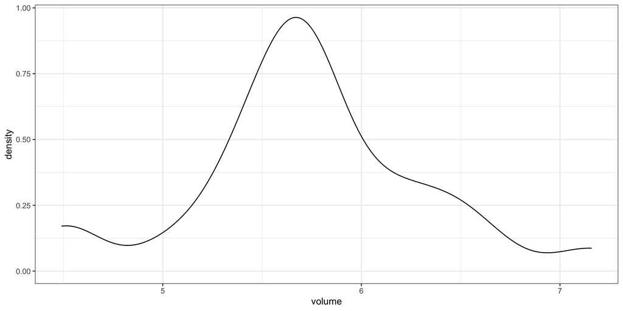

```r
concussion_subjects %>% ggplot(aes(x = volume)) + geom_density() + theme_bw()
```

## Example

- Now, we can plug in the information we have ($n = 25, \bar{y} = 5.735, \sigma = 0.5$) into our likelihood,

$$L(\mu|\overset{\to}y) \propto \exp \left\{ \frac{-(5.735 - \mu)^2}{2(0.5^2/25)} \right\}$$

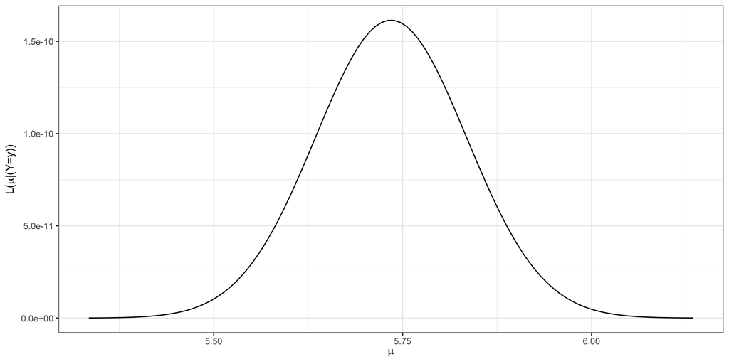

## Example

- We are now ready to put together our posterior:
  - Data distribution, $Y_i | \mu \overset{\text{iid}} \sim N(\mu, \sigma^2)$
  - Prior distribution, $\mu \sim N(\theta, \tau^2)$
  - Posterior distribution, $\mu | \overset{\to}y \sim N\left( \theta \frac{\sigma^2}{n\tau^2 + \sigma^2} + \bar{y} \frac{n\tau^2}{n\tau^2 + \sigma^2}, \frac{\tau^2 \sigma^2}{n \tau^2 + \sigma^2} \right)$
- Given our information ($\theta=6.5$, $\tau=0.4$, $n=25$, $\bar{y}=5.735$, $\sigma=0.5$), our posterior is

$$\mu | \overset{\to}y \sim N\left( \theta \frac{\sigma^2}{n\tau^2 + \sigma^2} + \bar{y} \frac{n\tau^2}{n\tau^2 + \sigma^2}, \frac{\tau^2 \sigma^2}{n \tau^2 + \sigma^2} \right)$$

## Example

- Given our information ($\theta=6.5$, $\tau=0.4$, $n=25$, $\bar{y}=5.735$, $\sigma=0.5$), our posterior is

$$\begin{align*}
\mu | \overset{\to}y &\sim N\left( \theta \frac{\sigma^2}{n\tau^2 + \sigma^2} + \bar{y} \frac{n\tau^2}{n\tau^2 + \sigma^2}, \frac{\tau^2 \sigma^2}{n \tau^2 + \sigma^2} \right) \\
&\sim N\left( 6.5 \frac{0.5^2}{25 \cdot 0.4^2 + 0.5^2} + 5.735 \frac{25 \cdot 0.4^2}{25 \cdot 0.4^2 + 0.5^2}, \frac{0.4^2 \cdot 0.5^2}{25 \cdot 0.4^2 + 0.5^2} \right) \\
&\sim N(6.5 \cdot 0.0588 + 5.737 \cdot 0.9412, 0.09^2) \\
&\sim N(5.78, 0.09^2)
\end{align*}$$

## Example

- Looking at just the prior and data distributions,

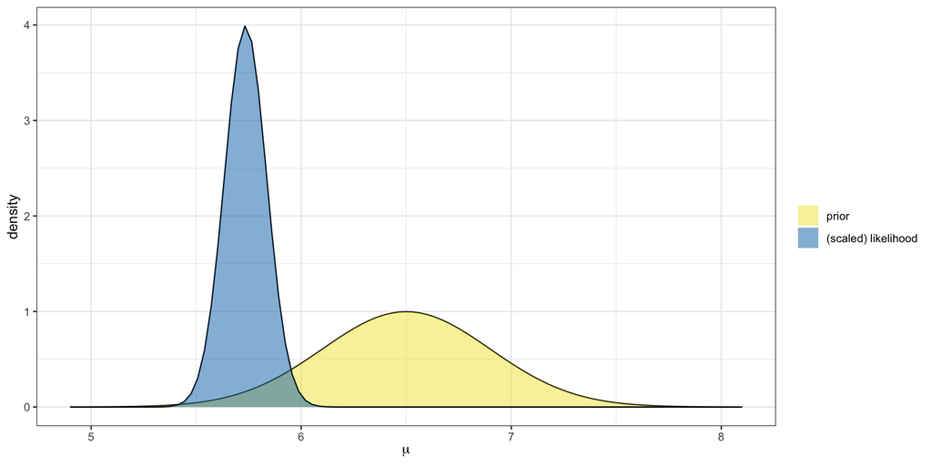

## Example

- Now including the posterior,

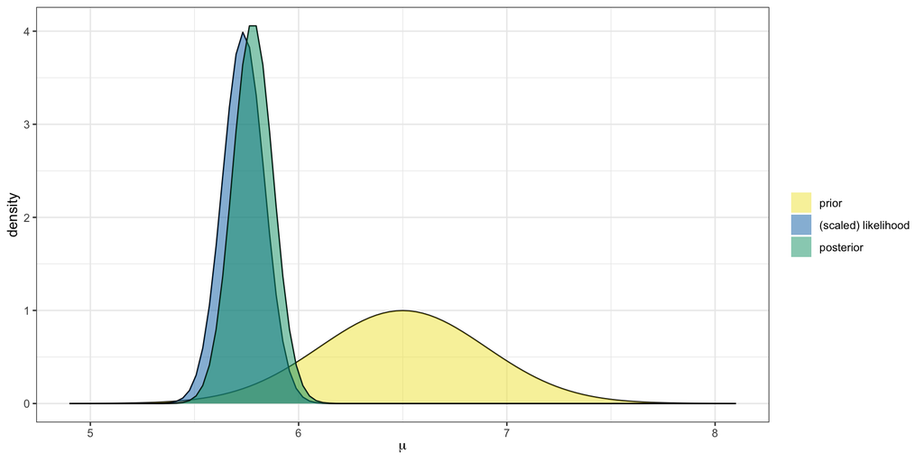

## Example

- We can use the `summarize_normal_normal()` function to summarize the distribution,

```r
summarize_normal_normal(mean = 6.5, sd = 0.4, sigma = 0.5, y_bar = 5.735, n = 25)
```

| model | mean | mode | var | sd |
| --- | --- | --- | --- | --- |
| prior | 6.50 | 6.50 | 0.160000000 | 0.40000000 |
| posterior | 5.78 | 5.78 | 0.009411765 | 0.09701425 |

## Wrap Up: Normal-Normal Model

- We have built the Normal-Normal model for $\mu$, an unknown mean.

$$\begin{equation*}
\begin{aligned}
Y_i | \mu &\overset{\text{iid}} \sim N(\mu, \sigma^2) \\
\mu &\sim N(\theta, \tau^2) &
\end{aligned}
\Rightarrow
\begin{aligned}
&& \mu | \overset{\to}y &\sim N\left( \theta \frac{\sigma^2}{n\tau^2 + \sigma^2} + \bar{y} \frac{n\tau^2}{n\tau^2 + \sigma^2}, \frac{\tau^2 \sigma^2}{n \tau^2 + \sigma^2} \right) \\
\end{aligned}
\end{equation*}$$

- The prior model, $f(\mu)$, is given by N($\theta,\tau^2$).
- The data model, $f(Y|\mu)$, is given by N($\mu, \sigma^2$).
- The posterior model is a Normal distribution with updated parameters
  - mean = $\theta \frac{\sigma^2}{n\tau^2 + \sigma^2} + \bar{y} \frac{n\tau^2}{n\tau^2 + \sigma^2}$
  - variance = $\frac{\tau^2 \sigma^2}{n \tau^2 + \sigma^2}$

## Wrap Up

- Today we have learned about the *conjugate families*.
  - Beta-Binomial: binary outcomes
  - Gamma-Poisson: count outcomes
  - Normal-Normal: continuous outcomes
- While we are not forced to analyze our data using conjugate families, our lives are much easier when we can use the known relationships.
- Note that while we did not do this with our posteriors in this lecture, we can now move forward with drawing conclusions about the posterior distribution.
  - Probabilities
  - Inference

## Homework

- 3.3
- 3.9
- 3.10
- 3.18
- 5.3
- 5.5
- 5.6
- 5.9
- 5.10